# Предобработка данных

```python
import numpy as np   # Библиотека для матриц, векторов и линала
import pandas as pd  # Библиотека для табличек
import matplotlib.pyplot as plt
```

```python
df=pd.read_csv('Данные для проекта.csv')
df.drop(columns=['Unnamed: 0'], inplace=True)
df['Дата']=pd.to_datetime(df['Дата'])
# превращение в индекс
df.set_index('Дата', inplace=True)
```

[output not shown]

[output cut: 1939 more lines]

[output not shown]

```python
df.shape
```

```
(1577, 11)
```

```python
## проверяем наличие пропусков
df.isnull().sum()
```

```
Доллар США           0
Евро                 0
Фунт стерлингов      0
Китайский юань       0
Японская йена        0
value_RUB           21
value_USD           39
value_EUR          289
value_GBP           28
value_JPY          103
value_CNY          408
dtype: int64
```

В наших данных достаточно много пропусков. Посмотрим, с чем это связано

```python
df[df.isnull().any(axis=1)]
```

| Дата | Доллар США | Евро | Фунт стерлингов | Китайский юань | Японская йена | value_RUB | value_USD | value_EUR | value_GBP | value_JPY | value_CNY |
| --- | --- | --- | --- | --- | --- | --- | --- | --- | --- | --- | --- |
| 2023-12-05 | 75,8846 | 82,8877 | 95,7512 | 10,9119 | 56,5881 | 7,50 | 5.06143 | NaN | 4.68770 | NaN | 1.320 |
| 2023-11-05 | 76,6929 | 84,1498 | 96,7251 | 11,0390 | 56,7465 | 7,50 | 5.06171 | NaN | 4.68100 | NaN | 1.102 |
| 2023-05-05 | 78,6139 | 86,9986 | 98,5268 | 11,3488 | 57,1654 | 7,50 | 5.05986 | NaN | 4.63360 | NaN | 1.234 |
| 2023-04-05 | 79,3071 | 87,5750 | 98,9118 | 11,4456 | 57,6695 | 7,50 | 5.05871 | NaN | 4.63370 | NaN | 1.658 |
| 2023-03-05 | 79,9609 | 87,6556 | 100,4789 | 11,4884 | 58,1449 | 7,50 | 4.81086 | NaN | 4.62320 | NaN | NaN |
| ... | ... | ... | ... | ... | ... | ... | ... | ... | ... | ... | ... |
| 2015-05-22 | 49,9204 | 55,5714 | 77,8858 | 80,5584 | 41,2924 | 12,50 | 0.12400 | -0.17643 | 0.57063 | 0.07000 | NaN |
| 2015-05-21 | 49,7919 | 55,2441 | 77,1774 | 80,2603 | 41,1622 | 12,50 | 0.12400 | -0.17786 | 0.56688 | 0.07143 | NaN |
| 2015-05-20 | 49,1777 | 55,1085 | 76,5943 | 79,2307 | 40,9797 | 12,50 | 0.12400 | -0.17786 | 0.56688 | 0.06714 | NaN |
| 2015-05-19 | 49,2175 | 56,1030 | 77,0992 | 79,3280 | 41,1260 | 12,50 | 0.12400 | -0.17786 | 0.56688 | 0.06571 | NaN |
| 2015-05-15 | 50,0774 | 57,1383 | 78,9420 | 80,7505 | 42,0148 | 12,50 | 0.12400 | -0.17786 | 0.56688 | 0.06857 | NaN |

692 rows × 11 columns

Дело в том, что по ставкам ЛИБОР по евро и йене за последние года нет данных - мы приняли решение проинтерполировать в них значения последнего "не-НаНа", то есть сильно предполагая, что ставка не поменялась. Конечно, это фикция, но удалять данные будет неправильно, поскольку по значительно большей части лет данные есть. Срезать года тоже не хотелось бы, так как данные по остальным валютам за поздние сроки имеются + хочется построить более или менее актуальную модель, которая не получится на данных только до конца 2021 года (уж слишком много всего поменялось, хи-хи). Заменять на моду или среднее тоже так себе вариант, потому что ставки слишком разные в годах, а где-то - только растут, поэтому на более поздние периоды не стоит понижать их до средних показателей.

```python
df['value_RUB']=df['value_RUB'].interpolate(method='time')
df['value_USD']=df['value_USD'].interpolate(method='time')
df['value_EUR']=df['value_EUR'].interpolate(method='time')
df['value_GBP']=df['value_GBP'].interpolate(method='time')
df['value_JPY']=df['value_JPY'].interpolate(method='time')
df['value_CNY']=df['value_CNY'].interpolate(method='time')
df.isnull().sum()
```

```
Доллар США           0
Евро                 0
Фунт стерлингов      0
Китайский юань       0
Японская йена        0
value_RUB           21
value_USD            0
value_EUR          264
value_GBP            0
value_JPY           67
value_CNY            0
dtype: int64
```

Как мы видим, не все пропуски удалось заменить с помощью интерполяции, так как было задано направление интерполяции forward, что идет в питоне по умолчанию. Проставим теперь оставшимся сатвкам направление backward, чтобы значения интерполировались с предыдущих известных.

```python
df['value_RUB']=df['value_RUB'].interpolate(limit_direction ='backward', method='time')
df['value_EUR']=df['value_EUR'].interpolate(limit_direction ='backward', method='time')
df['value_JPY']=df['value_JPY'].interpolate(limit_direction ='backward', method='time')
df.isnull().sum()
```

```
Доллар США          0
Евро                0
Фунт стерлингов     0
Китайский юань      0
Японская йена       0
value_RUB          21
value_USD           0
value_EUR           0
value_GBP           0
value_JPY           0
value_CNY           0
dtype: int64
```

Видим, что с рублевой ставкой все равно что-то не выходит: посмотрим, где конкретно НаНы и что нам с ними делать в таком случае

```python
df[df['value_RUB'].isnull()]
```

| Дата | Доллар США | Евро | Фунт стерлингов | Китайский юань | Японская йена | value_RUB | value_USD | value_EUR | value_GBP | value_JPY | value_CNY |
| --- | --- | --- | --- | --- | --- | --- | --- | --- | --- | --- | --- |
| 2023-08-03 | 75,4577 | 80,5496 | 90,5643 | 10,8672 | 55,4469 | NaN | 4.55814 | -0.64957 | 4.36080 | -0.06005 | 1.6480 |
| 2023-02-23 | 74,7087 | 79,5716 | 90,6889 | 10,8398 | 55,4219 | NaN | 4.56457 | -0.64957 | 4.26120 | -0.06005 | 1.4750 |
| 2022-04-11 | 62,0955 | 60,6071 | 71,1801 | 84,3037 | 42,0872 | NaN | 3.81629 | -0.64957 | 3.43260 | -0.06005 | 1.3860 |
| 2021-12-31 | 74,2926 | 84,0695 | 100,0573 | 11,6503 | 64,5097 | NaN | 0.06438 | -0.64957 | 0.26225 | -0.05183 | 2.1290 |
| 2021-04-11 | 71,4876 | 82,8112 | 97,3733 | 11,1745 | 62,7828 | NaN | 0.06900 | -0.58714 | 0.22525 | -0.06817 | 1.8860 |
| 2020-04-11 | 80,0006 | 93,3447 | 103,7208 | 11,9623 | 76,4861 | NaN | 0.08150 | -0.58286 | 0.04375 | -0.09783 | 1.4490 |
| 2020-01-07 | 70,4413 | 78,9929 | 86,5724 | 99,5806 | 65,4264 | NaN | 0.07663 | -0.56857 | 0.15090 | -0.06933 | 1.9670 |
| 2020-06-24 | 68,8376 | 77,6832 | 86,0263 | 97,4292 | 64,2861 | NaN | 0.07425 | -0.56143 | 0.15550 | -0.08200 | 1.5400 |
| 2020-12-06 | 69,1219 | 78,5225 | 87,6673 | 97,7624 | 64,6090 | NaN | 0.06613 | -0.56429 | 0.19760 | -0.09817 | 1.5290 |
| 2020-01-05 | 72,7263 | 79,1189 | 90,6679 | 10,3130 | 68,1980 | NaN | 0.05838 | -0.56955 | 0.55250 | -0.05217 | 1.8890 |
| 2019-09-05 | 65,2287 | 73,0888 | 85,1495 | 96,3311 | 59,2208 | NaN | 2.35888 | -0.47429 | 0.80963 | -0.09850 | 1.5130 |
| 2019-01-05 | 64,6314 | 72,3096 | 83,8592 | 95,9293 | 58,0591 | NaN | 2.39188 | -0.46863 | 0.81925 | -0.11150 | 2.3466 |
| 2019-08-03 | 65,9646 | 74,5730 | 86,8292 | 98,3519 | 59,0314 | NaN | 2.38688 | -0.46471 | 0.84600 | -0.11450 | 2.0470 |
| 2018-09-05 | 63,0066 | 75,0409 | 85,1093 | 98,9379 | 57,8069 | NaN | 1.70500 | -0.43771 | 0.68379 | -0.04733 | 2.5200 |
| 2018-08-03 | 56,8011 | 70,5299 | 78,8002 | 89,8339 | 53,6898 | NaN | 1.44688 | -0.44186 | 0.59994 | -0.07417 | 2.5700 |
| 2018-02-23 | 56,7608 | 69,6341 | 78,8805 | 89,2325 | 52,8819 | NaN | 1.44813 | -0.44371 | 0.57281 | -0.04400 | 2.5970 |
| 2017-08-03 | 58,2630 | 61,7063 | 71,1391 | 84,4575 | 51,1775 | NaN | 0.68211 | -0.42214 | 0.35206 | -0.05986 | 2.4061 |
| 2017-02-23 | 57,4762 | 60,4535 | 71,8050 | 83,5629 | 50,7180 | NaN | 0.68333 | -0.41714 | 0.35431 | -0.01414 | 2.5271 |
| 2016-04-11 | 63,5043 | 70,5977 | 78,4278 | 93,9288 | 61,7356 | NaN | 0.43511 | -0.40714 | 0.40644 | -0.04914 | 2.4943 |
| 2015-04-11 | 63,8525 | 70,3782 | 98,4478 | 10,0773 | 52,8909 | NaN | 0.13100 | -0.18000 | 0.57813 | 0.04943 | 2.4943 |
| 2015-12-06 | 54,5285 | 61,4754 | 84,2683 | 87,8543 | 44,1526 | NaN | 0.12300 | -0.17857 | 0.57125 | 0.06000 | 2.4943 |

Может, у нас не тот тип данных?

```python
df.dtypes
```

```
Доллар США          object
Евро                object
Фунт стерлингов     object
Китайский юань      object
Японская йена       object
value_RUB           object
value_USD          float64
value_EUR          float64
value_GBP          float64
value_JPY          float64
value_CNY          float64
dtype: object
```

Ну конечно! Нужно сделать object-ы float-ами, чтобы это были числовые данные. Сначала поменяем запятые в числах на точки, только так питон увидит именно числа

```python
df['value_RUB']=df['value_RUB'].astype(str)
#без этого питон не хотел работать со строковыми данными в след пункте
```

```python
df['Доллар США'] = [x.replace(',', '.') for x in df['Доллар США']]
df['Евро'] = [x.replace(',', '.') for x in df['Евро']]
df['Фунт стерлингов'] = [x.replace(',', '.') for x in df['Фунт стерлингов']]
df['Китайский юань'] = [x.replace(',', '.') for x in df['Китайский юань']]
df['Японская йена'] = [x.replace(',', '.') for x in df['Японская йена']]
df['value_RUB'] = [x.replace(',', '.') for x in df['value_RUB']]
df
```

| Дата | Доллар США | Евро | Фунт стерлингов | Китайский юань | Японская йена | value_RUB | value_USD | value_EUR | value_GBP | value_JPY | value_CNY |
| --- | --- | --- | --- | --- | --- | --- | --- | --- | --- | --- | --- |
| 2023-12-05 | 75.8846 | 82.8877 | 95.7512 | 10.9119 | 56.5881 | 7.50 | 5.06143 | -0.64957 | 4.68770 | -0.06005 | 1.320000 |
| 2023-11-05 | 76.6929 | 84.1498 | 96.7251 | 11.0390 | 56.7465 | 7.50 | 5.06171 | -0.64957 | 4.68100 | -0.06005 | 1.102000 |
| 2023-05-05 | 78.6139 | 86.9986 | 98.5268 | 11.3488 | 57.1654 | 7.50 | 5.05986 | -0.64957 | 4.63360 | -0.06005 | 1.234000 |
| 2023-04-05 | 79.3071 | 87.5750 | 98.9118 | 11.4456 | 57.6695 | 7.50 | 5.05871 | -0.64957 | 4.63370 | -0.06005 | 1.658000 |
| 2023-03-05 | 79.9609 | 87.6556 | 100.4789 | 11.4884 | 58.1449 | 7.50 | 4.81086 | -0.64957 | 4.62320 | -0.06005 | 1.388818 |
| ... | ... | ... | ... | ... | ... | ... | ... | ... | ... | ... | ... |
| 2015-05-22 | 49.9204 | 55.5714 | 77.8858 | 80.5584 | 41.2924 | 12.50 | 0.12400 | -0.17643 | 0.57063 | 0.07000 | 2.494300 |
| 2015-05-21 | 49.7919 | 55.2441 | 77.1774 | 80.2603 | 41.1622 | 12.50 | 0.12400 | -0.17786 | 0.56688 | 0.07143 | 2.494300 |
| 2015-05-20 | 49.1777 | 55.1085 | 76.5943 | 79.2307 | 40.9797 | 12.50 | 0.12400 | -0.17786 | 0.56688 | 0.06714 | 2.494300 |
| 2015-05-19 | 49.2175 | 56.1030 | 77.0992 | 79.3280 | 41.1260 | 12.50 | 0.12400 | -0.17786 | 0.56688 | 0.06571 | 2.494300 |
| 2015-05-15 | 50.0774 | 57.1383 | 78.9420 | 80.7505 | 42.0148 | 12.50 | 0.12400 | -0.17786 | 0.56688 | 0.06857 | 2.494300 |

1577 rows × 11 columns

```python
# сделаем все чиселками
df=df.astype(float)
df
```

| Дата | Доллар США | Евро | Фунт стерлингов | Китайский юань | Японская йена | value_RUB | value_USD | value_EUR | value_GBP | value_JPY | value_CNY |
| --- | --- | --- | --- | --- | --- | --- | --- | --- | --- | --- | --- |
| 2023-12-05 | 75.8846 | 82.8877 | 95.7512 | 10.9119 | 56.5881 | 7.5 | 5.06143 | -0.64957 | 4.68770 | -0.06005 | 1.320000 |
| 2023-11-05 | 76.6929 | 84.1498 | 96.7251 | 11.0390 | 56.7465 | 7.5 | 5.06171 | -0.64957 | 4.68100 | -0.06005 | 1.102000 |
| 2023-05-05 | 78.6139 | 86.9986 | 98.5268 | 11.3488 | 57.1654 | 7.5 | 5.05986 | -0.64957 | 4.63360 | -0.06005 | 1.234000 |
| 2023-04-05 | 79.3071 | 87.5750 | 98.9118 | 11.4456 | 57.6695 | 7.5 | 5.05871 | -0.64957 | 4.63370 | -0.06005 | 1.658000 |
| 2023-03-05 | 79.9609 | 87.6556 | 100.4789 | 11.4884 | 58.1449 | 7.5 | 4.81086 | -0.64957 | 4.62320 | -0.06005 | 1.388818 |
| ... | ... | ... | ... | ... | ... | ... | ... | ... | ... | ... | ... |
| 2015-05-22 | 49.9204 | 55.5714 | 77.8858 | 80.5584 | 41.2924 | 12.5 | 0.12400 | -0.17643 | 0.57063 | 0.07000 | 2.494300 |
| 2015-05-21 | 49.7919 | 55.2441 | 77.1774 | 80.2603 | 41.1622 | 12.5 | 0.12400 | -0.17786 | 0.56688 | 0.07143 | 2.494300 |
| 2015-05-20 | 49.1777 | 55.1085 | 76.5943 | 79.2307 | 40.9797 | 12.5 | 0.12400 | -0.17786 | 0.56688 | 0.06714 | 2.494300 |
| 2015-05-19 | 49.2175 | 56.1030 | 77.0992 | 79.3280 | 41.1260 | 12.5 | 0.12400 | -0.17786 | 0.56688 | 0.06571 | 2.494300 |
| 2015-05-15 | 50.0774 | 57.1383 | 78.9420 | 80.7505 | 42.0148 | 12.5 | 0.12400 | -0.17786 | 0.56688 | 0.06857 | 2.494300 |

1577 rows × 11 columns

```python
# теперь повторим интерполяцию для рублевой ставки
df['value_RUB']=df['value_RUB'].interpolate(limit_direction ='backward', method='time')
df.isnull().sum()
```

```
Доллар США         0
Евро               0
Фунт стерлингов    0
Китайский юань     0
Японская йена      0
value_RUB          0
value_USD          0
value_EUR          0
value_GBP          0
value_JPY          0
value_CNY          0
dtype: int64
```

Ура! Получилось убрать пропуски. Сохраним данные в файл csv, чтобы потом в анализе работать с уже обработанными

```python
df.to_csv('new_data.csv')
```

Пропусков в наших данных нет, поэтому можем переходить дальше. Мы считаем, что необходимо построить графики динамики курсов валют и ставок овернайт (ключевой рублевой или либор для других валют), чтобы увидеть, что с данными все более или менее в порядке, по курсам валют также можно увидеть исторические тенденции, кризисы и влияние каких-либо внешних шоков в соответствующие года

```python
def dynamic_graph_curr(column):
    column=str(column)
    # the name of the currency
    df[column].plot()
    plt.title(column)
    plt.ylabel('Обратный курс к рублю')
    plt.xlabel('Дата')
    plt.show();
```

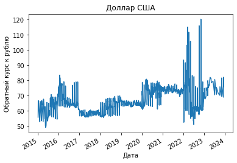

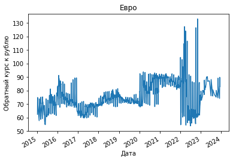

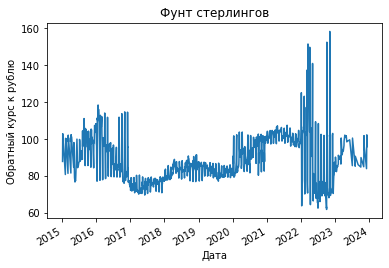

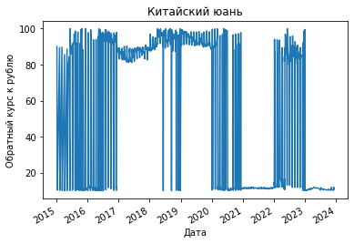

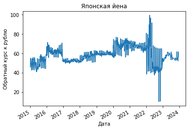

```python
dynamic_graph('Доллар США'), dynamic_graph('Евро'), dynamic_graph('Фунт стерлингов'), dynamic_graph('Китайский юань'), dynamic_graph('Японская йена');
```

```python
def dynamic_graph_rate(column):
    column=str(column)
    # the name of the rate
    df[column].plot()
    plt.title(column)
    plt.ylabel('Ставка овернайт')
    plt.xlabel('Дата')
    plt.show();
```

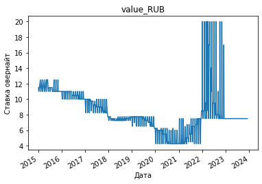

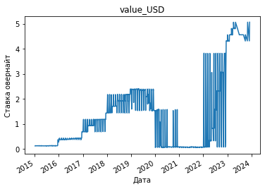

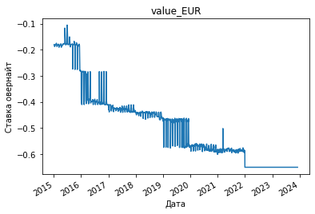

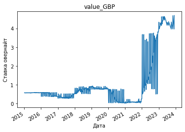

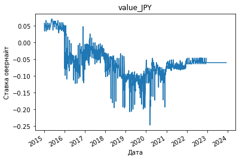

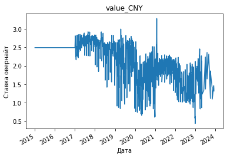

```python
dynamic_graph_rate('value_RUB'), dynamic_graph_rate('value_USD'), dynamic_graph_rate('value_EUR'), dynamic_graph_rate('value_GBP'), dynamic_graph_rate('value_JPY'), dynamic_graph_rate('value_CNY');
```

В целях предобработки данных мы хотим посмотреть на распределение значений курсов валют и ставок овернайт, посмотреть на выбросы в данных

```python
def distrib_curr(column):
    column=str(column)
    # the name of the currency
    df[column].hist()
    plt.title('Распределение валюты '+ column)
    plt.ylabel('Частота')
    plt.xlabel('Обратный курс к рублю')
    plt.show();
def distrib_rate(column):
    column=str(column)
    # the name of the rate
    df[column].hist()
    plt.title('Распределение ставки '+ column)
    plt.ylabel('Частота')
    plt.xlabel('Ставка овернайт')
    plt.show();
```

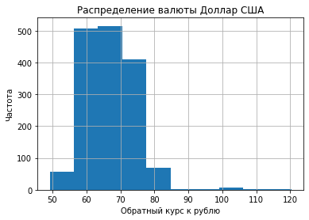

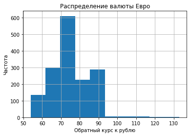

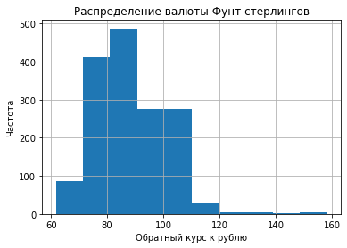

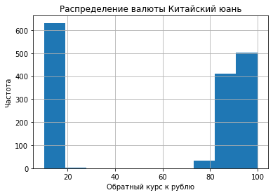

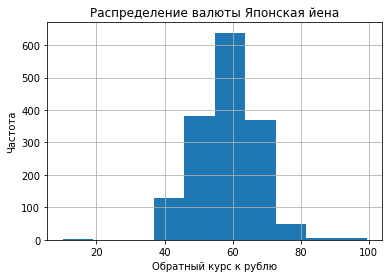

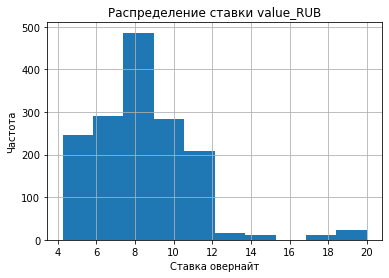

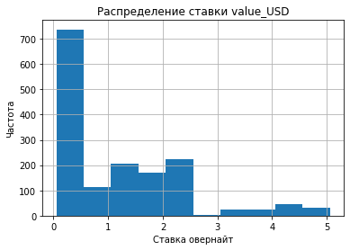

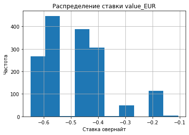

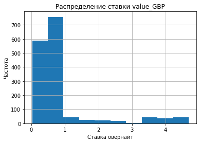

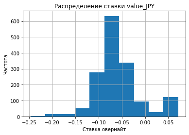

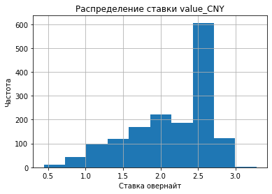

```python
distrib_curr('Доллар США'), distrib_curr('Евро'), distrib_curr('Фунт стерлингов'), distrib_curr('Китайский юань'), distrib_curr('Японская йена'), distrib_rate('value_RUB'), distrib_rate('value_USD'), distrib_rate('value_EUR'), distrib_rate('value_GBP'), distrib_rate('value_JPY'), distrib_rate('value_CNY');
```